# VIBRANT clinical data - merging CRFs data into wide tables

Author

Laura Vermeren, Lara Wautier, Céline Bugli, Laura Symul

Published

October 20, 2025

The purpose of this document is to create

- a `participant_crfs_merged` table: a table with one row per `pid` with “harmonized” participant-invariant data (*i.e.*, with data from CRFs that were filled only once per participant such as Demographics, Elligibility, etc.).
- `visits_crfs_merged` table: a table with one row per `pid` and `visit_code` with “harmonized” time-varying data (*i.e.*, with data from CRFs that were filled at several visits).

# `participant_crfs_merged` table

```r
data_dir <- get_01_output_dir()

crf_clean_file <-
  data_dir |> fs::dir_ls() |> str_subset("01_crf_clean") |> sort(decreasing = TRUE) |> magrittr::extract(1)
load(crf_clean_file, verbose = TRUE)
```

```
Loading objects:
  crf_clean
```

```r
# crf_clean |> names()
rm(crf_clean_file)
```

This table will merge (“join”) the data from the following CRFs which were expected to be filled only once for each participant:

```r
participants_crf_name <-
  c("crf1", "crf101", "crf2", "crf102",
    "crf5",
    "crf6", "crf7",
    "crf8", "crf9", "crf10", "crf11", "crf12", "crf13", "crf15",
    "crf22", "crf23","crf24", "crf25", "crf28",
    "crf43", "crf44","crf46"
    )

participants_crf_name
```

```
 [1] "crf1"   "crf101" "crf2"   "crf102" "crf5"   "crf6"   "crf7"   "crf8"
 [9] "crf9"   "crf10"  "crf11"  "crf12"  "crf13"  "crf15"  "crf22"  "crf23"
[17] "crf24"  "crf25"  "crf28"  "crf43"  "crf44"  "crf46"
```

## Correction of crfs with participants with multiple entries

Although these CRFs were supposed to be filled only once per participant, some participants have multiple entries in some CRFs.

Here, we create a function which, for each CRF listed above, compares the rows corresponding to duplicated `pid`s.

- If the rows are identical (*i.e.*, have same values for all columns except `dfseq`, `visit_code` and `study_day`), rows are “merged” (we only keep one of the two rows).
- If the lines are not identical, they are left as such in the CRFs and will be examined manually later.

In addition, this function removes the `dfseq` and `study_day` variables from these CRFs.

```r
process_crf_duplicates <- function(crf_clean, participants_crf_name) {

  participants_crf_filtered <-
    crf_clean[names(crf_clean) %in% participants_crf_name]

  for (crf_name in participants_crf_name) {

    data <- crf_clean[[crf_name]]

    dup_pid <-
      data |>
      dplyr::count(pid) |>
      dplyr::filter(n > 1) |>
      pull(pid)

    if(!("study_day" %in% names(data))) {
      data <-
        data |>
        mutate(study_day = NA_integer_)
    }
    if(!("dfseq" %in% names(data))) {
      data <-
        data |>
        mutate(dfseq = NA_integer_)
    }

    if(!("visit_code" %in% names(data))) {
      data <-
        data |>
        mutate(visit_code = NA_integer_)
    }
    if(!("uid" %in% names(data))) {
      data <-
        data |>
        mutate(uid = NA_character_)
    }

    if (length(dup_pid) > 0) {
      data <-
        data |>
        distinct(across(-c(dfseq, study_day, visit_code, uid)), .keep_all = TRUE)

      participants_crf_filtered[[crf_name]] <- data

    } else {
      participants_crf_filtered[[crf_name]] <- data #|> select(-c(dfseq, study_day))
    }

}

  return(participants_crf_filtered)
}

participants_crf <- process_crf_duplicates(crf_clean, participants_crf_name)
```

A list of CRFs that still contain duplicates is displayed below. We will examine them manually.

```r
for (crf_name in participants_crf_name) {
  data <- participants_crf[[crf_name]]

  dup_pid <-
    data |>
    dplyr::count(pid) |>
    dplyr::filter(n > 1) |>
    pull(pid)

  if (length(dup_pid) > 0) {
    print(crf_name)
  }
}
```

```
[1] "crf1"
[1] "crf101"
[1] "crf2"
[1] "crf102"
[1] "crf5"
[1] "crf6"
[1] "crf7"
[1] "crf8"
[1] "crf9"
[1] "crf10"
[1] "crf11"
[1] "crf12"
[1] "crf15"
[1] "crf22"
[1] "crf23"
[1] "crf24"
[1] "crf25"
[1] "crf28"
[1] "crf46"
```

### CRF 1

For this CRF, we keep the first observation for each participant.

```r
participants_crf[["crf1"]] <-
  participants_crf[["crf1"]] |>
  mutate(site = "MGH")

pid_temp <- participants_crf[["crf1"]] |>
  dplyr::count(pid) |>
  dplyr::filter(n > 1) |>
  pull(pid)

participants_crf[["crf1"]] |>
  filter(pid %in% pid_temp)
```

```
# A tibble: 4 × 17
  uid         pid   visit_code dfseq vdate_fixed study_day other_pronoun_specify
  <chr>       <chr> <chr>      <dbl> <lgl>           <dbl> <chr>
1 068100053_… 0681… 0000           0 FALSE             -15 <NA>
2 068100053_… 0681… 0010          10 NA                 NA <NA>
3 068100059_… 0681… 0000           0 FALSE              -6 <NA>
4 068100059_… 0681… 0010          10 NA                 NA <NA>
# ℹ 10 more variables: other_gender_specify <chr>, other_race_specify <chr>,
#   other_level_education_specify <chr>, age <int>, preferred_pronouns <chr>,
#   gender_identity <chr>, race <fct>, ethn <fct>, edu <fct>, site <chr>
```

```r
participants_crf[["crf1"]] <-
  participants_crf[["crf1"]] |>
  group_by(pid) |>
  arrange(dfseq) |>
  slice_head(n = 1) |>
  ungroup() |>
  mutate(
    site = "MGH"
  )
```

### CRF 101

We keep the highest value for `edu` and `income_sources` (*i.e.*, the most complete). All the other variables are kept as is.

Note : participant 200156 is the only one not to have the shortest value of income resource included in the largest value, so we correct it manually.

```r
# crf101

pid_temp <- participants_crf[["crf101"]] |>
  dplyr::count(pid) |>
  dplyr::filter(n > 1) |>
  pull(pid)

participants_crf[["crf101"]] |>
  dplyr::filter(pid %in% pid_temp)
```

```
# A tibble: 30 × 12
   uid     pid   visit_code dfseq vdate_fixed study_day   age preferred_pronouns
   <chr>   <chr> <chr>      <dbl> <lgl>           <dbl> <int> <chr>
 1 068200… 0682… 0000           0 FALSE             -22    32 She/Her
 2 068200… 0682… 0010          10 FALSE               0    32 She/Her
 3 068200… 0682… 0000           0 FALSE             -35    29 She/Her
 4 068200… 0682… 0010          10 FALSE               0    29 She/Her
 5 068200… 0682… 0000           0 NA                 NA    NA <NA>
 6 068200… 0682… 0010          10 FALSE               0    29 She/Her
 7 068200… 0682… 0000           0 FALSE            -217    19 She/Her
 8 068200… 0682… 0010          10 FALSE               0    19 She/Her
 9 068200… 0682… 0000           0 FALSE             -19    38 She/Her
10 068200… 0682… 0010          10 FALSE               0    38 She/Her
# ℹ 20 more rows
# ℹ 4 more variables: gender_identity <chr>, race <fct>, edu <fct>,
#   income_sources <fct>
```

```r
# 30 participants with double pid


education_levels <- c("Primary school", "Secondary school", "Tertiary education")

participants_crf[["crf101"]] <-
  participants_crf[["crf101"]] |>
  mutate(
    income_sources = case_when(
      pid == "200156" ~ "employed_full_time, family_support, husband_provides, social_grants",
      TRUE ~ income_sources
    )
  ) |>
  group_by(pid) |>
  summarise(
    across(-c(edu, income_sources), ~ dplyr::first(.x)),
    edu = edu[which.max(match(edu, education_levels))],

    income_sources = income_sources[which.max(str_count(income_sources, ",") + 1)],

    .groups = "drop"
  ) |>
  mutate(
    site = "CAP"
  )

rm(pid_temp, education_levels)
```

We combine the demographics data from `crf1` and `crf101` into a single table called `crf1_101`.

```r
participants_crf[["crf1_101"]] <- bind_rows(
  participants_crf[["crf1"]],
  participants_crf[["crf101"]]
)
```

We check the number of participants with duplicated pid values in the crf1_101 table. Some participants appear twice, with one of the entries containing no data. Therefore, we retain only the rows that contain actual data.

```r
pid_temp <- participants_crf[["crf1_101"]] |>
  dplyr::count(pid) |>
  dplyr::filter(n > 1) |>
  pull(pid)

participants_crf[["crf1_101"]] |>
  dplyr::filter(pid %in% pid_temp) |>
  arrange(pid)
```

```
# A tibble: 26 × 18
   uid        pid   visit_code dfseq vdate_fixed study_day other_pronoun_specify
   <chr>      <chr> <chr>      <dbl> <lgl>           <dbl> <chr>
 1 068200112… 0682… 0000           0 NA                 NA <NA>
 2 068200112… 0682… 0000           0 FALSE               0 <NA>
 3 068200178… 0682… 0000           0 NA                 NA <NA>
 4 068200178… 0682… 0000           0 FALSE               0 <NA>
 5 068200191… 0682… 0000           0 NA                 NA <NA>
 6 068200191… 0682… 0000           0 FALSE              -9 <NA>
 7 068200215… 0682… 0000           0 NA                 NA <NA>
 8 068200215… 0682… 0000           0 FALSE               0 <NA>
 9 068200218… 0682… 0000           0 NA                 NA <NA>
10 068200218… 0682… 0000           0 FALSE               0 <NA>
# ℹ 16 more rows
# ℹ 11 more variables: other_gender_specify <chr>, other_race_specify <chr>,
#   other_level_education_specify <chr>, age <int>, preferred_pronouns <chr>,
#   gender_identity <chr>, race <fct>, ethn <fct>, edu <fct>, site <chr>,
#   income_sources <chr>
```

```r
participants_crf[["crf1_101"]] <-
  participants_crf[["crf1_101"]] |>
  dplyr::filter(if_any(-c(uid, pid, dfseq, visit_code, site, study_day), ~ !is.na(.)))

#remove crf1 and 101 from the participant_crf
participants_crf[["crf1"]] <- NULL
participants_crf[["crf101"]] <- NULL
```

### CRF 2

For double entries, if a participant ever reported to worry for any the “worry” variables, then we keep the “Checked” value (worst case scenario).

```r
# crf2

pid_temp <- participants_crf[["crf2"]] |>
  dplyr::count(pid) |>
  dplyr::filter(n > 1) |>
  pull(pid)

participants_crf[["crf2"]] |>
  dplyr::filter(pid %in% pid_temp)
```

```
# A tibble: 6 × 18
  uid    pid   visit_code dfseq additional_income annual_gross_income worry_food
  <chr>  <chr> <chr>      <int> <fct>             <fct>               <chr>
1 06810… 0681… 0000           0 No                $70,000 - $140,000  Unchecked
2 06810… 0681… 0010          10 No                $70,000 - $140,000  Unchecked
3 06810… 0681… 0000           0 No                $30.000 - $70,000   Checked
4 06810… 0681… 0010          10 <NA>              <NA>                <NA>
5 06810… 0681… 0000           0 Yes               $70,000 - $140,000  Checked
6 06810… 0681… 0010          10 <NA>              <NA>                <NA>
# ℹ 11 more variables: worry_utilities <chr>, worry_rent <chr>,
#   worry_student_loans <chr>, worry_education_fees <chr>,
#   worry_mortgage <chr>, worry_childcare <chr>, worry_medical_bills <chr>,
#   worry_none <chr>, primary_income <fct>, additional_income_type <fct>,
#   study_day <int>
```

```r
# 6 participants with double pid

# if worry was "checked" and "uncheked" keep the worry "checked"
worry_cols <- names(participants_crf[["crf2"]])[str_detect(names(participants_crf[["crf2"]]), "^worry_")]
other_cols <- setdiff(names(participants_crf[["crf2"]]), c("pid", worry_cols))

participants_crf[["crf2"]] <-
  participants_crf[["crf2"]] |>
  group_by(pid) |>
  summarise(
    across(all_of(other_cols), ~ dplyr::first(.x)),
    across(all_of(worry_cols), ~ if ("Checked" %in% .x) "Checked" else "Unchecked"),
    .groups = "drop"
  )

rm(pid_temp, worry_cols, other_cols)
```

### CRF 102

Response for the `monthly_gross_income` is incoherent between the two visits (see table below).

We decide to keep the most recent visit.

```r
#crf102

pid_temp <- participants_crf[["crf102"]] |>
  dplyr::count(pid) |>
  dplyr::filter(n > 1) |>
  pull(pid)

participants_crf[["crf102"]] |>
  dplyr::filter(pid %in% pid_temp) |>
  group_by(pid) |>
  gt(row_group_as_column = TRUE)
```

|  | uid | visit_code | Visit code | monthly_gross_income | Ever worry about - food | Ever worry about - utilities | Ever worry about - rent | Ever worry about - student loans | Ever worry about - education loans | Ever worry about - mortgage | Ever worry about - childcare | Ever worry about - medical bills | Ever worry about - none of above | study_day |
| --- | --- | --- | --- | --- | --- | --- | --- | --- | --- | --- | --- | --- | --- | --- |
| 068200008 | 068200008_0000 | 0000 | 0 | > R3500 | Checked | Unchecked | Unchecked | Unchecked | Checked | Unchecked | Unchecked | Unchecked | Unchecked | NA |
|  | 068200008_0010 | 0010 | 10 | R1001-R3500 per month | Unchecked | Unchecked | Unchecked | Unchecked | Unchecked | Unchecked | Unchecked | Checked | Unchecked | NA |
| 068200012 | 068200012_0000 | 0000 | 0 | R1001-R3500 per month | Unchecked | Unchecked | Unchecked | Unchecked | Checked | Unchecked | Unchecked | Unchecked | Unchecked | NA |
|  | 068200012_0010 | 0010 | 10 | Less than R1000 per month | Unchecked | Unchecked | Unchecked | Unchecked | Checked | Unchecked | Unchecked | Unchecked | Unchecked | NA |
| 068200057 | 068200057_0000 | 0000 | 0 | NA | NA | NA | NA | NA | NA | NA | NA | NA | NA | NA |
|  | 068200057_0010 | 0010 | 10 | R1001-R3500 per month | Checked | Unchecked | Unchecked | Checked | Checked | Unchecked | Checked | Checked | Unchecked | NA |
| 068200067 | 068200067_0000 | 0000 | 0 | R1001-R3500 per month | Checked | Checked | Unchecked | Unchecked | Unchecked | Unchecked | Unchecked | Unchecked | Unchecked | NA |
|  | 068200067_0010 | 0010 | 10 | Prefer not to answer | Unchecked | Unchecked | Unchecked | Unchecked | Unchecked | Unchecked | Unchecked | Unchecked | Checked | NA |
| 068200095 | 068200095_0000 | 0000 | 0 | > R3500 | Checked | Unchecked | Unchecked | Unchecked | Unchecked | Unchecked | Checked | Unchecked | Unchecked | NA |
|  | 068200095_0010 | 0010 | 10 | Less than R1000 per month | Checked | Unchecked | Unchecked | Unchecked | Unchecked | Unchecked | Checked | Unchecked | Unchecked | NA |
| 068200125 | 068200125_0000 | 0000 | 0 | R1001-R3500 per month | Checked | Unchecked | Unchecked | Unchecked | Unchecked | Unchecked | Checked | Unchecked | Unchecked | NA |
|  | 068200125_0010 | 0010 | 10 | Less than R1000 per month | Checked | Unchecked | Unchecked | Unchecked | Unchecked | Unchecked | Checked | Unchecked | Unchecked | NA |
| 068200131 | 068200131_0000 | 0000 | 0 | Less than R1000 per month | Checked | Unchecked | Unchecked | Unchecked | Unchecked | Unchecked | Unchecked | Unchecked | Unchecked | NA |
|  | 068200131_0010 | 0010 | 10 | R1001-R3500 per month | Checked | Unchecked | Unchecked | Unchecked | Unchecked | Unchecked | Unchecked | Unchecked | Unchecked | NA |
| 068200148 | 068200148_0000 | 0000 | 0 | > R3500 | Checked | Unchecked | Unchecked | Unchecked | Unchecked | Unchecked | Unchecked | Unchecked | Unchecked | NA |
|  | 068200148_0010 | 0010 | 10 | NA | NA | NA | NA | NA | NA | NA | NA | NA | NA | NA |
| 068200156 | 068200156_0000 | 0000 | 0 | > R3500 | Checked | Unchecked | Unchecked | Unchecked | Checked | Unchecked | Unchecked | Unchecked | Unchecked | NA |
|  | 068200156_0010 | 0010 | 10 | > R3500 | Unchecked | Unchecked | Unchecked | Unchecked | Checked | Unchecked | Unchecked | Unchecked | Unchecked | NA |
| 068200327 | 068200327_0000 | 0000 | 0 | Prefer not to answer | Unchecked | Unchecked | Checked | Unchecked | Unchecked | Unchecked | Unchecked | Unchecked | Unchecked | NA |
|  | 068200327_0010 | 0010 | 10 | Less than R1000 per month | Checked | Unchecked | Unchecked | Unchecked | Unchecked | Unchecked | Unchecked | Unchecked | Unchecked | NA |

```r
participants_crf[["crf102"]] <-
  participants_crf[["crf102"]] |>
  group_by(pid) |>
  arrange(-dfseq) |>
  slice_head(n = 1) |>
  ungroup()

rm(pid_temp)
```

We combine the socio demographics data from `crf2` and `crf102` into a single table called `crf2_102`.

```r
participants_crf[["crf2_102"]] <- bind_rows(
  participants_crf[["crf2"]],
  participants_crf[["crf102"]]
)
```

We check the number of participants with duplicated pid values in the crf2_102 table. Some participants from MGH appear twice, with one of the entries containing no data. Therefore, we retain only the rows that contain actual data for those participants. Some participants from CAP appear twice, with one of the entries containing no data for the `mothly_gross_income`. Therefore, we retain only the rows that contain the annual gross income for those participants.

```r
pid_temp <- participants_crf[["crf2_102"]] |>
  dplyr::count(pid) |>
  dplyr::filter(n > 1) |>
  pull(pid)

participants_crf[["crf2_102"]] |>
  dplyr::filter(pid %in% pid_temp) |>
  arrange(pid)
```

```
# A tibble: 30 × 19
   pid       uid          visit_code dfseq additional_income annual_gross_income
   <chr>     <chr>        <chr>      <int> <fct>             <fct>
 1 068100009 068100009_0… 0000           0 No                $30.000 - $70,000
 2 068100009 068100009_0… 0000           0 <NA>              <NA>
 3 068100012 068100012_0… 0000           0 No                $30.000 - $70,000
 4 068100012 068100012_0… 0000           0 <NA>              <NA>
 5 068200112 068200112_0… 0000           0 <NA>              <NA>
 6 068200112 068200112_0… 0000           0 <NA>              <NA>
 7 068200178 068200178_0… 0000           0 <NA>              <NA>
 8 068200178 068200178_0… 0000           0 <NA>              <NA>
 9 068200191 068200191_0… 0000           0 <NA>              <NA>
10 068200191 068200191_0… 0000           0 <NA>              <NA>
# ℹ 20 more rows
# ℹ 13 more variables: primary_income <fct>, additional_income_type <fct>,
#   study_day <int>, worry_food <chr>, worry_utilities <chr>, worry_rent <chr>,
#   worry_student_loans <chr>, worry_education_fees <chr>,
#   worry_mortgage <chr>, worry_childcare <chr>, worry_medical_bills <chr>,
#   worry_none <chr>, monthly_gross_income <fct>
```

```r
participants_crf[["crf2_102"]] <-
  participants_crf[["crf2_102"]] |>
  dplyr::filter(if_any(-c(uid, pid, visit_code, dfseq), ~ !is.na(.)))

crf_temp <-
  participants_crf[["crf2_102"]] |>
  dplyr::filter(pid %in% pid_temp) |>
  dplyr::filter(!is.na(monthly_gross_income))

participants_crf[["crf2_102"]] <-
  participants_crf[["crf2_102"]] |>
  dplyr::filter(!(pid %in% crf_temp$pid)) |>
  bind_rows(crf_temp)

rm(pid_temp, crf_temp)

# Remove crf2 and 102 from the participant_crf
participants_crf[["crf2"]] <- NULL
participants_crf[["crf102"]] <- NULL
```

### CRF 5

```r
pid_temp <-
  participants_crf[["crf5"]] |>
  dplyr::count(pid) |>
  dplyr::filter(n > 1) |>
  pull(pid)

participants_crf[["crf5"]] |>
  dplyr::filter(pid %in% pid_temp)
```

```
# A tibble: 85 × 9
   pid       no_pre_existing_cond…¹ diagnosis ongoing_enrollment ongoing_at_exit
   <chr>     <lgl>                  <chr>     <chr>              <chr>
 1 068100010 FALSE                  Shelfish… Yes                Yes
 2 068100010 FALSE                  Fruit al… Yes                Yes
 3 068100010 FALSE                  Egg alle… Yes                Yes
 4 068100010 FALSE                  Latex al… Yes                Yes
 5 068100010 FALSE                  Asthma    Yes                Yes
 6 068100010 FALSE                  Depressi… Yes                Yes
 7 068100010 FALSE                  Eczema    Yes                Yes
 8 068100011 FALSE                  Eczema    Yes                Yes
 9 068100011 FALSE                  Asthma    Yes                Yes
10 068100011 FALSE                  Peanut a… Yes                Yes
# ℹ 75 more rows
# ℹ abbreviated name: ¹no_pre_existing_condition
# ℹ 4 more variables: study_day <int>, dfseq <int>, visit_code <int>, uid <chr>
```

```r
participants_crf[["crf5"]] <-
  participants_crf[["crf5"]]  |>
  group_by(pid)  |>
  summarise(
    no_pre_existing_condition =
      if(length(unique(no_pre_existing_condition)) == 1) unique(no_pre_existing_condition)
      else paste(unique(no_pre_existing_condition), collapse = " & "),

    diagnosis_agg = paste(diagnosis, collapse = " & "),

    ongoing_enrollment = {
      if(length(unique(ongoing_enrollment)) == 1) {
        unique(ongoing_enrollment)
      } else {
        paste(
          sapply(1:n(), function(i) {
            if(ongoing_enrollment[i] != ongoing_enrollment[1]) paste0(ongoing_enrollment[i], " (", diagnosis[i], ")") else ongoing_enrollment[i]
          }),
          collapse = " & "
        ) |>
        unique()
      }
    },
    ongoing_at_exit =
      if(length(unique(ongoing_at_exit)) == 1) unique(ongoing_at_exit)
    else {
      paste(
        sapply(1:n(), function(i) {
          if(ongoing_at_exit[i] != ongoing_at_exit[1]) paste0(ongoing_at_exit[i], " (", diagnosis[i], ")") else ongoing_at_exit[i]
        }),
        collapse = " & "
      )  |>
      unique()
    }
  )
```

### CRF 6

We keep the values of the most recent visit.

```r
# crf6


pid_temp <-
  participants_crf[["crf6"]] |>
  dplyr::count(pid) |>
  dplyr::filter(n > 1) |>
  pull(pid)
pid_temp
```

```
 [1] "068100009" "068100019" "068100053" "068100059" "068200008" "068200009"
 [7] "068200011" "068200012" "068200017" "068200037" "068200038" "068200057"
[13] "068200067" "068200087" "068200096" "068200128" "068200131" "068200148"
[19] "068200154" "068200156" "068200162" "068200169" "068200172" "068200173"
[25] "068200174" "068200179" "068200201" "068200216" "068200224" "068200255"
[31] "068200256" "068200267" "068200278" "068200279" "068200288" "068200304"
[37] "068200325" "068200327" "068200350"
```

```r
participants_crf[["crf6"]] |>
  dplyr::filter(pid %in% pid_temp)
```

```
# A tibble: 78 × 25
   uid          pid   visit_code dfseq vdate_fixed study_day age   premenopausal
   <chr>        <chr> <chr>      <dbl> <lgl>           <dbl> <chr> <chr>
 1 068100009_0… 0681… 0000           0 FALSE            -133 Yes   Yes
 2 068100009_0… 0681… 0010          10 FALSE               0 Yes   Yes
 3 068100019_0… 0681… 0000           0 FALSE             -19 Yes   Yes
 4 068100019_0… 0681… 0010          10 FALSE               0 Yes   Yes
 5 068100053_0… 0681… 0000           0 FALSE             -15 Yes   Yes
 6 068100053_0… 0681… 0010          10 FALSE              -7 Yes   Yes
 7 068100059_0… 0681… 0000           0 FALSE              -6 Yes   Yes
 8 068100059_0… 0681… 0010          10 FALSE               0 Yes   Yes
 9 068200008_0… 0682… 0000           0 FALSE             -37 Yes   Yes
10 068200008_0… 0682… 0010          10 FALSE              -8 Yes   Yes
# ℹ 68 more rows
# ℹ 17 more variables: abnormal_nugent_score <chr>, amesel3 <chr>,
#   hiv_uninfected <chr>, not_pregnant <chr>, on_contraceptives <chr>,
#   informed_consent <chr>, attend_study_visits <chr>,
#   history_uterine_disease <chr>, hysterectomy <chr>,
#   cervicovaginal_infection <chr>, yeast_infection <chr>,
#   vaginal_antibiotics <chr>, syphilis <chr>, …
```

```r
#78 participants with double pid

participants_crf[["crf6"]] <-
  participants_crf[["crf6"]] |>
  group_by(pid) |>
  arrange(-study_day) |>
  slice_head(n = 1) |>
  ungroup() |>
  dplyr::rename(
    age_at_consent = age
  )

rm(pid_temp)
```

### CRF 7

We keep the values of the most recent visit.

```r
# crf7

pid_temp <- participants_crf[["crf7"]] |>
  dplyr::count(pid) |>
  dplyr::filter(n > 1) |>
  pull(pid)

participants_crf[["crf7"]] |>
  dplyr::filter(pid %in% pid_temp)
```

```
# A tibble: 56 × 19
   uid         pid   visit_code dfseq current_medications history_medical_cond…¹
   <chr>       <chr> <chr>      <int> <chr>               <chr>
 1 068100019_… 0681… 0000           0 No                  No
 2 068100019_… 0681… 0010          10 No                  No
 3 068100053_… 0681… 0000           0 No                  No
 4 068100053_… 0681… 0010          10 No                  No
 5 068100059_… 0681… 0000           0 No                  No
 6 068100059_… 0681… 0010          10 No                  No
 7 068200008_… 0682… 0000           0 Not done            Not done
 8 068200008_… 0682… 0010          10 No                  No
 9 068200011_… 0682… 0000           0 Not done            Not done
10 068200011_… 0682… 0010          10 No                  No
# ℹ 46 more rows
# ℹ abbreviated name: ¹history_medical_conditions
# ℹ 13 more variables: iud_use <chr>, probiotic_use <chr>,
#   active_covid19_infection <chr>, vaginal_cleansing <chr>, menopause <chr>,
#   testosterone_use <chr>, blood_pressure <chr>, hemoglobin <chr>,
#   covid_vaccination <chr>, breastfeeding <chr>, condition_pi_opinion <chr>,
#   meet_eligibility <chr>, study_day <int>
```

```r
participants_crf[["crf7"]] <-
  participants_crf[["crf7"]] |>
  group_by(pid) |>
  arrange(-study_day) |>
  slice_head(n = 1) |>
  ungroup()

rm(pid_temp)
```

### CRF 8

We keep the values of the most recent visit.

```r
pid_temp <- participants_crf[["crf8"]] |>
  dplyr::count(pid) |>
  dplyr::filter(n > 1) |>
  pull(pid)
pid_temp
```

```
[1] "068200008" "068200009" "068200012" "068200087" "068200172"
```

```r
participants_crf[["crf8"]] |>
  dplyr::filter(pid %in% pid_temp) |>
  group_by(pid) |>
  gt(row_group_as_column = TRUE)
```

|  | uid | visit_code | dfseq | study_day | begin_hormone_contraception | start_hormone_contraception | date_start_menses | protection_type | number_pregnancies | unplanned_pregnancies | number_deliveries | diagnosed_bv | Treated for vaginal symptoms? | Past year treated for bv? |
| --- | --- | --- | --- | --- | --- | --- | --- | --- | --- | --- | --- | --- | --- | --- |
| 068200008 | 068200008_0000 | 0000 | 0 | -37 | Just for the study | NA | -44 | sanitary_pads_dispose | 2 | 0 | 2 | No | 3 | NA |
|  | 068200008_0010 | 0010 | 10 | -8 | Just for the study | NA | -44 | sanitary_pads_dispose | 2 | 2 | 2 | No | 1 | NA |
| 068200009 | 068200009_0000 | 0000 | 0 | -13 | Before hearing about the study | -144 | NA |  | 1 | 0 | 1 | No | 0 | NA |
|  | 068200009_0010 | 0010 | 10 | 0 | Before hearing about the study | -144 | NA | sanitary_pads_dispose | 1 | 0 | 1 | No | 0 | NA |
| 068200012 | 068200012_0000 | 0000 | 0 | -35 | Before hearing about the study | -2059 | NA |  | 2 | 2 | 1 | Blank | 0 | NA |
|  | 068200012_0010 | 0010 | 10 | 0 | Before hearing about the study | -1054 | 0 | sanitary_pads_dispose | 2 | 1 | 1 | No | 0 | NA |
| 068200087 | 068200087_0000 | 0000 | 0 | -21 | Before hearing about the study | -3912 | NA |  | 2 | 2 | 2 | Don't know | 2 | NA |
|  | 068200087_0010 | 0010 | 10 | -5 | Before hearing about the study | -3912 | NA |  | 2 | 2 | 2 | No | 2 | NA |
| 068200172 | 068200172_0000 | 0000 | 0 | -19 | Just for the study | NA | NA |  | 1 | 1 | 1 | Don't know | 0 | NA |
|  | 068200172_0010 | 0010 | 10 | 0 | Just for the study | NA | NA |  | 2 | 2 | 1 | No | 1 | NA |

```r
participants_crf[["crf8"]] <-
  participants_crf[["crf8"]] |>
  group_by(pid) |>
  arrange(-study_day) |>
  slice_head(n = 1) |>
  ungroup()

rm(pid_temp)
```

### CRF 9

```r
pid_temp <-
  participants_crf[["crf9"]] |>
  dplyr::count(pid) |>
  dplyr::filter(n > 1) |>
  pull(pid)

pid_temp
```

```
[1] "068200172"
```

```r
participants_crf[["crf9"]] |>
  dplyr::filter(pid %in% pid_temp)
```

```
# A tibble: 2 × 8
  pid       uid         dfseq antibiotic_type treatment_type STIs_type study_day
  <chr>     <chr>       <int> <fct>           <fct>          <fct>         <int>
1 068200172 068200172_…     0 none            none           none             NA
2 068200172 068200172_…    10 do_not_know     other_treatme… dont_know        NA
# ℹ 1 more variable: visit_code <int>
```

```r
participants_crf[["crf9"]] <-
  participants_crf[["crf9"]] |>
  group_by(pid) |>
  arrange(-study_day) |>
  slice_head(n = 1) |>
  ungroup()

rm(pid_temp)
```

### CRF 10

```r
pid_temp <-
  participants_crf[["crf10"]] |>
  dplyr::count(pid) |>
  dplyr::filter(n > 1) |>
  pull(pid)
pid_temp
```

```
[1] "068200009" "068200012" "068200172"
```

```r
participants_crf[["crf10"]] |>
  dplyr::filter(pid %in% pid_temp) |>
  group_by(pid) |>
  gt(row_group_as_column = TRUE)
```

|  | uid | Visit code | relationship_type | How many sexual partners-lifetime | How many sexual partners-past month | 1-ever been relationship- were harmed | Current relationship - harmed | study_day | visit_code |
| --- | --- | --- | --- | --- | --- | --- | --- | --- | --- |
| 068200009 | 068200009_0000 | 0 | married_living_separately | 5 | 1 | Blank | No | NA | NA |
|  | 068200009_0010 | 10 | married_living_separately | 5 | 1 | Yes | No | NA | NA |
| 068200012 | 068200012_0000 | 0 | married_living_separately | 5 | 1 | No | No | NA | NA |
|  | 068200012_0010 | 10 | married_living_separately | 6 | 1 | No | No | NA | NA |
| 068200172 | 068200172_0000 | 0 | married_living_separately | 4 | 1 | Yes | No | NA | NA |
|  | 068200172_0010 | 10 | married_living_separately | 3 | 1 | Yes | No | NA | NA |

```r
participants_crf[["crf10"]] <-
  participants_crf[["crf10"]]|>
  group_by(pid) |>
  arrange(-study_day) |>
  slice_head(n = 1) |>
  ungroup()

rm(pid_temp)
```

### CRF 11

We keep the most recent visit.

```r
pid_temp <-
  participants_crf[["crf11"]] |>
  dplyr::count(pid) |>
  dplyr::filter(n > 1) |>
  pull(pid)
pid_temp
```

```
[1] 068200008 068200012 068200087 068200169 068200172 068200278
244 Levels: 068200008 068200009 068200011 068200012 068200017 ... 068200465
```

```r
participants_crf[["crf11"]] |>
  dplyr::filter(pid %in% pid_temp)
```

```
# A tibble: 12 × 15
   uid           pid   visit_code dfseq upset unable_to_control nervous_stressed
   <fct>         <fct> <fct>      <int> <fct> <fct>             <fct>
 1 068200008_00… 0682… 0000           0 0 = … 3 = Fairly often  3 = Fairly often
 2 068200008_00… 0682… 0010          10 2 = … 0 = Never         3 = Fairly often
 3 068200012_00… 0682… 0000           0 0 = … 0 = Never         0 = Never
 4 068200012_00… 0682… 0010          10 2 = … 2 = Sometimes     2 = Sometimes
 5 068200087_00… 0682… 0000           0 2 = … 2 = Sometimes     2 = Sometimes
 6 068200087_00… 0682… 0010          10 1 = … 2 = Sometimes     2 = Sometimes
 7 068200169_00… 0682… 0000           0 2 = … 2 = Sometimes     2 = Sometimes
 8 068200169_00… 0682… 0010          10 0 = … 1 = Almost never  0 = Never
 9 068200172_00… 0682… 0000           0 2 = … 2 = Sometimes     1 = Almost never
10 068200172_00… 0682… 0010          10 3 = … 4 = Very          4 = Very
11 068200278_00… 0682… 0000           0 2 = … 2 = Sometimes     2 = Sometimes
12 068200278_00… 0682… 0010          10 2 = … 2 = Sometimes     2 = Sometimes
# ℹ 8 more variables: confident <fct>, going_your_way <fct>,
#   could_not_cope <fct>, control_irritations <fct>, on_top_of_things <fct>,
#   outside_your_control <fct>, difficulties_piling_up <fct>, study_day <int>
```

```r
participants_crf[["crf11"]] <-
  participants_crf[["crf11"]] |>
  group_by(pid) |>
  arrange(-study_day) |>
  slice_head(n = 1) |>
  ungroup()

rm(pid_temp)
```

### CRF 12

We keep the most recent visit.

```r
pid_temp <-
  participants_crf[["crf12"]] |>
  dplyr::count(pid) |>
  dplyr::filter(n > 1) |>
  pull(pid)
pid_temp
```

```
[1] "068200012" "068200169" "068200172"
```

```r
participants_crf[["crf12"]] |>
  dplyr::filter(pid %in% pid_temp)
```

```
# A tibble: 6 × 11
  uid            pid   visit_code dfseq food_did_not_last not_afford_balanced_…¹
  <chr>          <chr> <chr>      <int> <chr>             <chr>
1 068200012_0000 0682… 0000           0 Sometimes true    Often true
2 068200012_0010 0682… 0010          10 Never true        Sometimes true
3 068200169_0000 0682… 0000           0 Sometimes true    Sometimes true
4 068200169_0010 0682… 0010          10 Sometimes true    Sometimes true
5 068200172_0000 0682… 0000           0 Sometimes true    Sometimes true
6 068200172_0010 0682… 0010          10 Sometimes true    Often true
# ℹ abbreviated name: ¹not_afford_balanced_meals
# ℹ 5 more variables: cut_size_meals <chr>, often_cut_size_meals <chr>,
#   eat_less <chr>, hungry_did_not_eat <chr>, study_day <int>
```

```r
participants_crf[["crf12"]] <-
  participants_crf[["crf12"]] |>
  group_by(pid) |>
  arrange(-dfseq) |>
  slice_head(n = 1) |>
  ungroup()

rm(pid_temp)
```

### CRF 15

```r
pid_temp <- participants_crf[["crf15"]] |>
  dplyr::count(pid) |>
  dplyr::filter(n > 1) |>
  pull(pid)
pid_temp
```

```
[1] "068100006" "068200008" "068200011" "068200085"
```

```r
participants_crf[["crf15"]] |>
  dplyr::filter(pid %in% pid_temp)
```

```
# A tibble: 8 × 8
  uid            pid    visit_code dfseq vdate_fixed study_day pap_smear_results
  <chr>          <chr>  <chr>      <dbl> <lgl>           <dbl> <chr>
1 068100006_0000 06810… 0000           0 NA                 NA <NA>
2 068100006_1000 06810… 1000        1000 FALSE               0 Negative for int…
3 068200008_0000 06820… 0000           0 NA                 NA <NA>
4 068200008_0010 06820… 0010          10 FALSE              -8 Negative for int…
5 068200011_0000 06820… 0000           0 NA                 NA <NA>
6 068200011_0010 06820… 0010          10 FALSE               0 Negative for int…
7 068200085_0000 06820… 0000           0 FALSE             -11 Negative for int…
8 068200085_1011 06820… 1011        1011 FALSE               2 <NA>
# ℹ 1 more variable: blood_type <chr>
```

```r
participants_crf[["crf15"]] <-
  participants_crf[["crf15"]] |>
  mutate(
    pap_smear_results = case_when(
      pid == 200085 ~ "Negative for intraepithelial lesion or cancer (malignancy)",
      TRUE ~ pap_smear_results
    ),
    blood_type = case_when(
      pid == 200085 ~ "AB positive (AB+)",
      TRUE ~ blood_type
    )
  ) |>
  group_by(pid) |>
  arrange(-dfseq) |>
  slice_head(n = 1) |>
  ungroup()
```

### CRF 22 (Metrodanizole exposure)

Data are used to create the exposure table.

Some participants came twice, either because they were in the overlap arm, or because they had not completed treatment at the first visit.

We keep the second observation for these participants.

We rename the variable `prescription_container` to `prescription_container_metronidazole`, `tablets_remain` to `tablets_remain_metronidazole` to avoid conflict with the data from CRF23 (study product exposure).

```r
pid_temp <-
  participants_crf[["crf22"]] |>
  dplyr::count(pid) |>
  dplyr::filter(n > 1) |>
  pull(pid)
pid_temp
```

```
 [1] "068100010" "068100011" "068200008" "068200020" "068200023" "068200028"
 [7] "068200050" "068200061" "068200118" "068200127" "068200131" "068200150"
[13] "068200179" "068200191" "068200214" "068200225" "068200229" "068200239"
[19] "068200247" "068200248" "068200252" "068200253" "068200350" "068200356"
[25] "068200357" "068200358" "068200361" "068200363" "068200364" "068200370"
[31] "068200373" "068200375" "068200378" "068200379" "068200385" "068200387"
[37] "068200388" "068200392" "068200397" "068200399" "068200407" "068200409"
[43] "068200412" "068200414" "068200415" "068200421" "068200422" "068200425"
[49] "068200428" "068200438" "068200439" "068200441" "068200460" "068200465"
```

```r
participants_crf[["crf22"]] |>
  dplyr::filter(pid %in% pid_temp)
```

```
# A tibble: 108 × 8
   uid    pid   visit_code dfseq study_day prescription_container tablets_remain
   <chr>  <chr> <chr>      <dbl>     <dbl> <chr>                           <int>
 1 06810… 0681… 1100        1100         5 Yes                                 3
 2 06810… 0681… 1200        1200        10 Yes                                 0
 3 06810… 0681… 1100        1100         6 Yes                                 5
 4 06810… 0681… 1200        1200        15 No                                 NA
 5 06820… 0682… 1100        1100         7 Yes                                 1
 6 06820… 0682… 1200        1200        15 Yes                                 0
 7 06820… 0682… 1100        1100         6 Yes                                 4
 8 06820… 0682… 1200        1200        17 No                                 NA
 9 06820… 0682… 1100        1100         7 Yes                                 1
10 06820… 0682… 1200        1200        15 Yes                                 0
# ℹ 98 more rows
# ℹ 1 more variable: metro_dose_miss <fct>
```

```r
participants_crf[["crf22"]] <-
  participants_crf[["crf22"]] |>
  group_by(pid) |>
  arrange(-study_day) |>
  slice_head(n = 1) |>
  ungroup() |>
  dplyr::rename(
    prescription_container_metronidazole = prescription_container,
    tablets_remain_metronidazole = tablets_remain,
    #comments_metronidazole = comments
  )
```

### CRF 23 (product exposure)

Data are used to create the exposure table. Some participants came twice because they were in the overlap arm or because they don’t finished the treatment at the first visit.

So we keep the second observation for these participants.

```r
pid_temp <-
  participants_crf[["crf23"]] |>
  dplyr::count(pid) |>
  dplyr::filter(n > 1) |>
  pull(pid)
pid_temp
```

```
 [1] "068100010" "068200020" "068200061" "068200150" "068200191" "068200239"
 [7] "068200253" "068200310" "068200358" "068200361" "068200364" "068200370"
[13] "068200379" "068200438" "068200465"
```

```r
participants_crf[["crf23"]] |>
  dplyr::filter(pid %in% pid_temp)
```

```
# A tibble: 30 × 12
   uid       pid   visit_code dfseq vdate_fixed study_day prescription_container
   <chr>     <chr> <chr>      <dbl> <lgl>           <dbl> <chr>
 1 06810001… 0681… 1100        1100 FALSE               5 Yes
 2 06810001… 0681… 1200        1200 FALSE              10 Yes
 3 06820002… 0682… 1100        1100 FALSE               6 Yes
 4 06820002… 0682… 1200        1200 FALSE              17 Yes
 5 06820006… 0682… 1100        1100 FALSE               7 Yes
 6 06820006… 0682… 1200        1200 FALSE              15 Yes
 7 06820015… 0682… 1100        1100 FALSE               6 Yes
 8 06820015… 0682… 1200        1200 FALSE              17 Yes
 9 06820019… 0682… 1100        1100 FALSE               7 Yes
10 06820019… 0682… 1200        1200 FALSE              15 Yes
# ℹ 20 more rows
# ℹ 5 more variables: tablets_remain <int>, used_applicators <chr>,
#   number_applicators <int>, n_missed_days <dbl>, product_missed_days <chr>
```

```r
participants_crf[["crf23"]] <-
  participants_crf[["crf23"]] |>
  group_by(pid) |>
  arrange(-study_day) |>
  slice_head(n = 1) |>
  ungroup() |>
  dplyr::rename(
    prescription_container_study_product = prescription_container,
    tablets_remain_study_product = tablets_remain,
    #comments_study_product = comments
  )
```

### CRF 24

We keep the most recent visit.

```r
pid_temp <-
  participants_crf[["crf24"]] |>
  dplyr::count(pid) |>
  dplyr::filter(n > 1) |>
  pull(pid)
pid_temp
```

```
 [1] 068100029 068100004 068100006 068100010 068100026 068100036 068100040
 [8] 068100052 068100053 068100060 068100061 068100063 068200008 068200023
[15] 068200028 068200050 068200058 068200061 068200062 068200085 068200087
[22] 068200127 068200131 068200150 068200191 068200214 068200225 068200229
[29] 068200240 068200278 068200281 068200282 068200285 068200347 068200356
[36] 068200357 068200358 068200361 068200364 068200366 068200375 068200397
[43] 068200399 068200412 068200415 068200421 068200422 068200438 068200441
[50] 068200460 068200465
92 Levels: 068100029 068100004 068100006 068100010 068100011 ... 068200425
```

```r
participants_crf[["crf24"]] |>
  dplyr::filter(pid %in% pid_temp)
```

```
# A tibble: 103 × 15
   uid       pid   visit_code dfseq vdate_fixed study_day accept_vaginal_inser…¹
   <fct>     <fct> <fct>      <dbl> <lgl>           <dbl>                  <int>
 1 06810000… 0681… 1200        1200 FALSE              14                      6
 2 06810000… 0681… 1500        1500 FALSE              34                      6
 3 06810000… 0681… 1200        1200 FALSE              15                      5
 4 06810000… 0681… 1500        1500 FALSE              33                      5
 5 06810001… 0681… 1200        1200 FALSE              10                      6
 6 06810001… 0681… 1500        1500 NA                 NA                     NA
 7 06810002… 0681… 1200        1200 FALSE              15                      5
 8 06810002… 0681… 1500        1500 FALSE              35                      5
 9 06810002… 0681… 1200        1200 FALSE              15                      6
10 06810002… 0681… 1500        1500 FALSE              35                      6
# ℹ 93 more rows
# ℹ abbreviated name: ¹accept_vaginal_insert_product
# ℹ 8 more variables: comfort_insertion_procedure <int>,
#   understand_insert_procedure <int>, size_of_tablet <int>,
#   comfortable_use_applicator <int>, comfortable_insert_product <int>,
#   insert_product_daily <int>, tell_partner <fct>, partner_comfortable <fct>
```

```r
participants_crf[["crf24"]] <-
  participants_crf[["crf24"]] |>
  group_by(pid) |>
  arrange(-study_day) |>
  slice_head(n = 1) |>
  ungroup()
```

### CRF 25

We keep the most recent visit.

```r
pid_temp <-
  participants_crf[["crf25"]] |>
  dplyr::count(pid) |>
  dplyr::filter(n > 1) |>
  pull(pid)

participants_crf[["crf25"]] |>
  dplyr::filter(pid %in% pid_temp)
```

```
# A tibble: 88 × 11
   uid         pid   visit_code dfseq reason_missed_doses product_shorter_longer
   <fct>       <fct> <fct>      <int> <fct>               <fct>
 1 068100006_… 0681… 1200        1200 I did not miss dos… Okay with 7 days
 2 068100006_… 0681… 1500        1500 I did not miss dos… Shorter
 3 068100010_… 0681… 1200        1200 I did not miss dos… Shorter
 4 068100010_… 0681… 1500        1500 <NA>                <NA>
 5 068100011_… 0681… 1200        1200 I did not miss dos… Longer
 6 068100011_… 0681… 1500        1500 I did not miss dos… Longer
 7 068100040_… 0681… 1200        1200 I did not miss dos… Shorter
 8 068100040_… 0681… 1500        1500 I did not miss dos… Shorter
 9 068100049_… 0681… 1200        1200 I did not miss dos… Shorter
10 068100049_… 0681… 1500        1500 I did not miss dos… Shorter
# ℹ 78 more rows
# ℹ 5 more variables: use_product_again <fct>, use_applicator_again <fct>,
#   product_benefit_you <fct>, product_shorter_longer_how_many <fct>,
#   study_day <int>
```

```r
participants_crf[["crf25"]] <-
  participants_crf[["crf25"]] |>
  group_by(pid) |>
  arrange(-study_day) |>
  slice_head(n = 1) |>
  ungroup()
```

### CRF 28

We keep the most recent visit.

```r
pid_temp <-
  participants_crf[["crf28"]] |>
  dplyr::count(pid) |>
  dplyr::filter(n > 1) |>
  pull(pid)
pid_temp
```

```
 [1] "068100049" "068100052" "068100053" "068100058" "068100059" "068100060"
 [7] "068200008" "068200011" "068200012" "068200017" "068200037" "068200038"
[13] "068200057" "068200085" "068200148" "068200214" "068200216" "068200397"
```

```r
participants_crf[["crf28"]] |>
  dplyr::filter(pid %in% pid_temp)
```

```
# A tibble: 36 × 11
   uid       pid   visit_code dfseq vdate_fixed study_day other_contraceptive_…¹
   <chr>     <chr> <chr>      <dbl> <lgl>           <dbl> <chr>
 1 06810004… 0681… 0000           0 TRUE              -15 <NA>
 2 06810004… 0681… 1000        1000 FALSE               0 <NA>
 3 06810005… 0681… 0000           0 FALSE             -15 <NA>
 4 06810005… 0681… 1000        1000 FALSE               0 <NA>
 5 06810005… 0681… 0000           0 FALSE             -15 <NA>
 6 06810005… 0681… 0010          10 FALSE              -7 <NA>
 7 06810005… 0681… 0000           0 FALSE              -7 <NA>
 8 06810005… 0681… 1000        1000 FALSE               0 <NA>
 9 06810005… 0681… 0000           0 FALSE              -6 <NA>
10 06810005… 0681… 0010          10 FALSE               0 <NA>
# ℹ 26 more rows
# ℹ abbreviated name: ¹other_contraceptive_specify
# ℹ 4 more variables: contraception_method <chr>, contraceptive_switch <chr>,
#   participant_contraceptive_switch <chr>, participant_eligible <chr>
```

```r
participants_crf[["crf28"]] <-
  participants_crf[["crf28"]] |>
  group_by(pid) |>
  arrange(-study_day) |>
  slice_head(n = 1) |>
  ungroup()
```

### CRF 46

We keep the first observation for these participants since the second observation is not complete.

```r
pid_temp <-
  participants_crf[["crf46"]] |>
  dplyr::count(pid) |>
  dplyr::filter(n > 1) |>
  pull(pid)

participants_crf[["crf46"]] |>
  dplyr::filter(pid %in% pid_temp)
```

```
# A tibble: 2 × 14
  uid            pid     visit_code dfseq vdate_fixed study_day negative_control
  <chr>          <chr>   <chr>      <dbl> <lgl>           <dbl> <chr>
1 068200370_1100 068200… 1100        1100 FALSE               7 No
2 068200370_1200 068200… 1200        1200 NA                 NA <NA>
# ℹ 7 more variables: positive_control <chr>, applicator_stain_positive <int>,
#   applicator_stain_negative <int>, applicator_stain_indeterminant <int>,
#   total_applicators_stained <int>, proportion_positive_applicators <dbl>,
#   total <int>
```

```r
participants_crf[["crf46"]] <-
  participants_crf[["crf46"]] |>
  group_by(pid) |>
  arrange(dfseq) |>
  slice_head(n = 1) |>
  ungroup()
```

## Making the `participant_crfs_merged` table

We check that the number of repeated `pid` per CRF is zero for each CRF.

```r
table_p <- map_df(
  names(participants_crf),
  function(participants_crf_name) {
    df <- participants_crf[[participants_crf_name]]

    if (!"pid" %in% names(df)) {
      return(tibble(crf = participants_crf_name, n_multi_pid = NA_integer_))
    }

    n <-
      df |>
      dplyr::count(pid) |>
      dplyr::filter(n > 1) |>
      nrow()

    tibble(crf = participants_crf_name, n_multi_pid = n)
  }
)

table_p
```

```
# A tibble: 20 × 2
   crf      n_multi_pid
   <chr>          <int>
 1 crf5               0
 2 crf6               0
 3 crf7               0
 4 crf8               0
 5 crf9               0
 6 crf10              0
 7 crf11              0
 8 crf12              0
 9 crf13              0
10 crf15              0
11 crf22              0
12 crf23              0
13 crf24              0
14 crf25              0
15 crf28              0
16 crf43              0
17 crf44              0
18 crf46              0
19 crf1_101           0
20 crf2_102           0
```

```r
# Select crf with 0 multi pids
participants_crf_name <-
  table_p |>
  filter(n_multi_pid == 0) |>
  pull(crf)
```

We now merge all the CRFs into a single table called `participant_crfs_merged`.

```r
participant_crfs_merged <-
  participants_crf[names(participants_crf) %in% participants_crf_name] |>
  map(
    function(df) {
      if ("dfseq" %in% names(df)) {df |> select(-any_of(c("uid", "visit_code","dfseq", "study_day", "vdate_fixed")))
      } else {df}
    }
  ) |>
  purrr::reduce(full_join, by = join_by(pid))


# participant_crfs_merged |> colnames() |> str_detect("\\.y") |> sum()
```

This table has 532 entries (unique participants) and 145 variables.

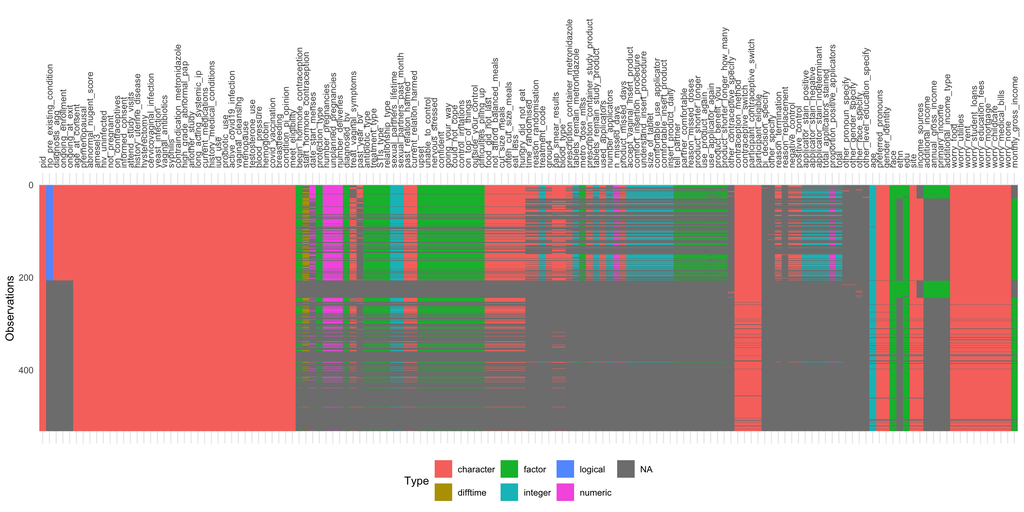

```r
visdat::vis_dat(
  participant_crfs_merged, sort_type = FALSE
  ) +
  theme(
    legend.position = "bottom",
    axis.text.x = element_text(angle = 90, hjust = 0, vjust = 0.5)
  )
```

# `visits_crfs_merged` table

We call “visit CRFs” any CRFs which was not present in the “participants CRF” list.

We further remove CRF 29 (Adverse events) and CRF 34 (Protocol deviation) because they does not contain `visit_code`.

```r
visits_crf_name <-
  setdiff(names(crf_clean[!names(crf_clean) %in% c("crf1", "crf101", "crf2", "crf102")]),
          participants_crf_name) |>
  setdiff("crf27_long")

#crf in visits_crf name but with no study_day variable
no_studyday <- crf_clean[names(crf_clean) %in% visits_crf_name] |>
  keep(~ !"study_day" %in% names(.x)) |>
  names()
no_studyday
```

```
[1] "crf17" "crf18" "crf19" "crf20" "crf21" "crf31" "crf33"
```

```r
#crf in visits_crf name but with no dfseq variable
no_dfseq <- crf_clean[names(crf_clean) %in% visits_crf_name] |>
  keep(~ !"dfseq" %in% names(.x)) |>
  names()
no_dfseq
```

```
[1] "crf29_summary" "crf31"         "crf47_long"
```

```r
visits_crf_name <-
  setdiff(visits_crf_name, no_dfseq) |>
  setdiff("crf29") |>
  setdiff("crf34")

visits_crf_name
```

```
 [1] "crf3"  "crf4"  "crf14" "crf16" "crf17" "crf18" "crf19" "crf20" "crf21"
[10] "crf26" "crf27" "crf30" "crf32" "crf33" "crf35" "crf40" "crf41" "crf42"
[19] "crf45" "crf47"
```

We now check that each CRF contains one row per participant and visit (*i.e.*, per `uid`).

In CRF14, one `uid` (=068100002_0000) appears four times. Three of these entries are identical, so we keep only one of them.

```r
process_crf_duplicates <- function(crf_clean, crf_names) {

  crf_filtered <-
    crf_clean[names(crf_clean) %in% crf_names]

  for (name in crf_names) {

    data <- crf_clean[[name]]

    dup_uid <-
      data |>
      dplyr::count(uid) |>
      dplyr::filter(n > 1) |>
      pull(uid)

    dup_uid

    if (length(dup_uid) > 0) {
      data <-
        data |>
        distinct()

      crf_filtered[[name]] <- data

    } else {
      crf_filtered[[name]] <- data #|> select(-c(dfseq, study_day))
    }

}

  return(crf_filtered)
}

visits_crf <- process_crf_duplicates(crf_clean, visits_crf_name)
```

For the uid 068100002_0000 in crf14, we keep the one for which we have data for nugent score (the rest is identical)

```r
visits_crf$crf14 <-
  visits_crf$crf14 |>
  filter(!(uid=="068100002_0000" & nugent_done == "Not done"))
```

```r
# first join crf that have dfseq and study_day
# visits_crfs_merged <-
#   crf_clean[setdiff(visits_crf_name, no_studyday)] |>
#   purrr::reduce(full_join, by = join_by(uid, pid, visit_code, dfseq, study_day))
crf_list_renamed <-
  crf_clean |>
  imap(function(df, name) {
    double_cols <- c("vaginal_discharge", "vaginal_bleeding", "put_in_vagina_type", "sex_past_24hours", "page")
    names(df)[names(df) %in% double_cols] <- paste0(names(df)[names(df) %in% double_cols], ".", name)
    df
  })

visits_crfs_merged <-
  crf_list_renamed[setdiff(visits_crf_name, no_studyday)] |>
  map(
    function(df) {
      df |> select(-any_of(c("uid", "vdate_fixed")))
    }
  ) |>
  purrr::reduce(full_join, by = join_by(pid, visit_code, dfseq, study_day))

# Then add crf with no study_day

visits_crfs_merged <-
  visits_crfs_merged |>
  full_join(
    crf_list_renamed[setdiff(no_studyday, no_dfseq)] |>
      map(
        function(df) {
          df |> select(-any_of(c("uid")))
        }
      ) |>
      purrr::reduce(full_join, by = join_by(pid, visit_code, dfseq)),
    by = join_by(pid, visit_code, dfseq)
  )

visits_crfs_merged |>
  select(any_of(colnames(visits_crfs_merged)[str_detect(colnames(visits_crfs_merged), "\\.x")]))
```

```
# A tibble: 4,662 × 0
```

We remove data for whic `hiv_result` is “missing” and for wich we have no other data.

```r
visits_crfs_merged <-
  visits_crfs_merged |>
  filter(!(hiv_results == "Missing"  & nugent_done == "Missing" &
             if_all(-c(pid, visit_code, dfseq, hiv_results, nugent_done), is.na))) |>
  distinct()
```

# Exports

We export the two merged tables as `Rdata` files.

```r
dir <- get_01_output_dir()

save(participant_crfs_merged, file = str_c(dir, "01_participant_crfs_merged_", today() |> str_replace_all("-",""), ".Rdata"))
save(visits_crfs_merged, file = str_c(dir, "01_visits_crfs_merged_", today() |> str_replace_all("-",""), ".Rdata"))
```